# Bookstore_Database_Design

## Business background

Book Moo Inc. is a small bookstore that offers a wide range of books across different genres like fiction, non-fiction, and children's books. Therefore, as a local market retailer, the business owners of the store want to provide a variety of high-quality books. In addition, they want to focus on excellent customer service and a personalized shopping experience for book lovers. Book Moo Inc. would greatly benefit from implementing a robust database system to enhance these offerings and overcome various business challenges.

#### Some question to understanding the business domain:

1-What are the main objectives you hope to achieve with the new database system?

2-What types of books do you sell, and how are they currently categorized? 3-How do you track your inventory, and what are the pain points in your current system?

4-Can you describe your current process for managing sales transactions?

5-How do you handle customer data, and what kind of information do you collect?

6-What are the key metrics or reports you need to generate regularly?

7-How do you manage supplier information and book orders?

8-What are the biggest challenges you face with your current system?

9-What security measures are currently in place to protect sensitive information?

10-How do you manage online sales, and how does this integrate with in-store operations?

11-Are there any compliance or regulatory requirements for the database?

12-What is your budget and timeline for implementing the new database system?

13-What are the key performance indicators (KPIs) you monitor, and how can the database help track these?

### Determine the entities assumptions and create the ER model:

Following many meetings and discussions, the Entity-Relationship (ER) model to represent the assumptions of entities, relationships, and cardinality constraints. The ER diagram will let stakeholders see how the entities capture the data, the different data types, and how the associated entities are connected. Below are entities that were confirmed with the stakeholders.

1- **Customers entity**: This table will store the customer's details, such as name, email, phone number, and address.

2- **Author entity**: This table will store the author's details, such as name, email, phone, and address.

3- **Orders entity**: This table will store information about the customer's orders, such as the order number, date, time, status, shipping address.

4- **Books entity**: This table will store information about the books in stock, such as the title, author, publisher, ISBN, and price.

5- **Category entity**: This table will store information about the categories of the books in stock, such as the category ID, name, and description.

6- **Publishers entity**: This table will store information about the publisher's details, such as the publisher ID, Name, Phone, Email, and Address.

7- **Inventories entity**: This table will store information about the inventory details such as the Book ISBN, Status, and Quantity.

8- **Payments entity**: This table will store information about the payment method, Payment date, status, and Amount used by the customer’s order.

9- **Reviews entity**: This table will store information about the reviews left by the customers, such as the review ID, Rating, and Comments.

### Business Rules (relationships between entities):

• A customer can place zero, or many orders but each order is placed by one and only one customer.

• A customer can write zero, or many reviews but each review is placed by one and only one customer.

• A category can have zero, or many books but Each book belongs to one and only one category. • Each book can have zero, or many inventory items, but each inventory item is associated with one and only one book.

• An author can write one, or many books but each book is written by one or many author.

• Each author can be associated with one, or many publishers, and each publisher can be associated with one, or many authors.

• Each order can include one, or many books, and each book can be included in one, or many orders.

• An order can have one, or many payments but each payment is associated with one and only one order.

• Each book can have zero, or many reviews, but each review is associated with one and only one book.

• Each book is associated with one and only one publisher, but a publisher can have one, or many books.

### Visualize the database structure ERD

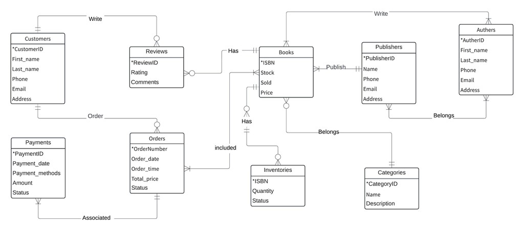

**Normalization steps to ensure that the database was free of redundancy and dependency issues. Moreover, to implement this step, I want to go through many steps:**

**a- Determine the primary keys for each entity.**

**b- Identify the relationships between entities by adding necessary foreign keys to represent those relationships.**

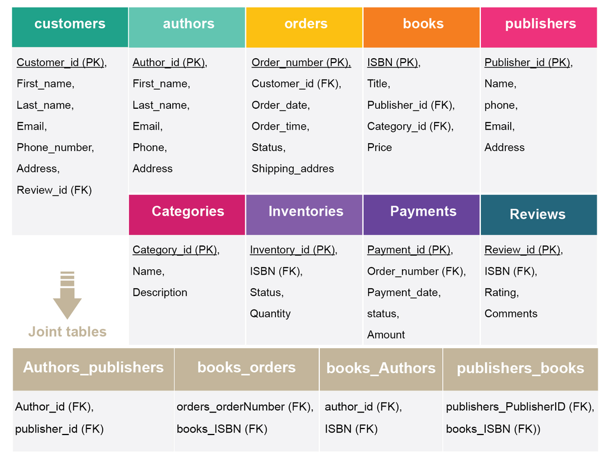

**c- After that I double checked for Functional Dependencies and 1NF, 2NF, and finally 3NF 1NF: All attributes are atomic.**

• an author can write one, or many books but each book is written by one or many author This is a many-to-many relationship, so I created an additional table **books_Authors**, with author_id and ISBN as foreign keys.

• Each author can be associated with one, or many publishers, and each publisher can be associated with one, or many authors. This is another many-to-many relationship, so create an additional table **Authors_publishers**, with author_id and publisher_id as foreign keys.

• Each order can include one, or many books, and each book can be included in one, or many orders. This is a many-to-many relationship, so create an additional table **books_orders**, with order_number and ISBN as foreign keys.

2NF: Remove partial dependencies (already done by proper foreign key placement above). 3NF: Remove transitive dependencies (i.e., no non-prime attribute should be dependent on another non-prime attribute).

**The Final Output for Implementation:**

1- customers: (Customer_id (PK), First_name, Last_name, Email, Phone_number, Address) FD1: Customer_id → First_name, Last_name, Email, Phone_number, Address, Review_id (FK) There are no other non-trivial dependencies since Customer_id uniquely determines all other attributes.

2- authors: (Author_id (PK), First_name, Last_name, Email, Phone, Address) FD1: Author_id → First_name, Last_name, Email, Phone, Address Again, Author_id uniquely determines all other attributes.

3- orders: (Order_number (PK), Customer_id (FK), Order_date, Order_time, Status, Shipping_address) FD1: Order_number→ Customer_id, Order_date, Order_time, Status, Shipping_address, Order_number uniquely determines all other attributes.

5- publishers: (Publisher_id (PK), Name, Phone, Email, Address) FD1: Publisher_id → Name, Phone, Email, Address Publisher_id uniquely determines all other attributes.

6- books_Authors: (Author_id (FK), ISBN (FK)) FD1: {Author_id, ISBN} → (no other attributes) There are no additional non-trivial dependencies since the table consists solely of the composite key.

7- Authors_publishers: (Author_id (FK), Publisher_id (FK)) FD1: {Author_id, Publisher_id} → (no other attributes) Again, no other non-trivial dependencies as it consists solely of the composite key.

8- books_orders: (Order_number (FK), ISBN (FK)) FD1: {Order_number , ISBN} → (no other attributes) There are no additional non-trivial dependencies since the table consists solely of the composite key.

9- publishers_books: (publishers_PublisherID (FK), ISBN (FK)) FD1: {publishers_PublisherID , books_ISBN} → (no other attributes) There are no additional non-trivial dependencies since the table consists solely of the composite key.

10- categories: (Category_id (PK), Name, Description) FD1: Category_id → Name, Description Category_id uniquely determines all other attributes.

11- inventories: (Inventory_id (PK), ISBN (FK), Status, Quantity) FD1: Inventory_id → ISBN, Status, Quantity Inventory_id uniquely determines all other attributes.

12- payments: (Payment_id (PK), Order_number (FK), Payment_date, Status, Amount) FD1: Payment_id → Order_number , Payment_date, Status, Amount Payment_id uniquely determines all other attributes.

13- reviews: (Review_id (PK), ISBN (FK), Rating, Comments, Customer_id (FK)) FD1: Review_id → ISBN, Rating, Comments Review_id uniquely determines all other attributes.

### Final Visualize the database structure ERD

So, after arriving at this structure, I am sure that all tables are in 3NF, with each non-key attribute fully functionally dependent on the primary key, ensuring minimal redundancy and maximum data integrity.

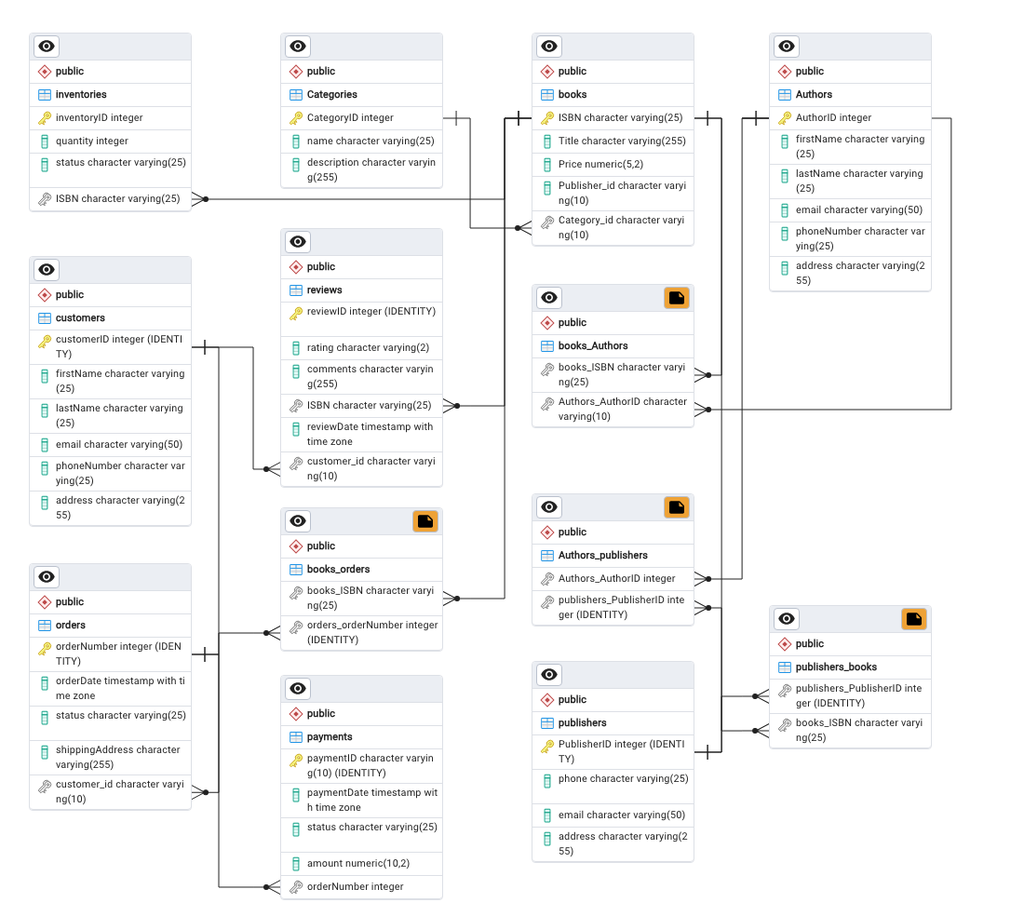